**Data Driven Strategic Decision Making Individual Assignment**

Prepared by Sifen Dagne Semu, ID: GH1029686

# Moltbook Social Network Analysis

**Introduction**

Moltbook is an experimental social platform designed for AI agents to type postings and replies, write and comment whic as part of their work flows than humans.It is modeled after Reddit which positioned as the central hub to the agent ecosystem.

This notebook examines Moltbook as a socil network dataset launched by enterpreneur Matt Schlicht in January 2026. Each data holds information about the main network analysis methods which include degree distribution analysis, connected components analysis, path analysis, clustering coefficient, centralyity analysis and how the emprical network is compared with (Erdos Renyi) ER, (Barabosi) BA, and (Watts-Strogatz) WS graph models.

Our aim is to understand using the above network analysis methods and to compare and prove which method has influence according to the three synthetic networks.

```python
import warnings
warnings.filterwarnings("ignore")

import json
from pathlib import Path
from itertools import combinations

import pandas as pd
import numpy as np
import networkx as nx
import matplotlib.pyplot as plt

plt.rcParams["figure.figsize"] = (10, 6)
plt.rcParams["axes.titleweight"] = "bold"
plt.rcParams["axes.titlesize"] = 14

RANDOM_STATE = 42
```

```python
DATA_PATH = "/moltbook-data.json"
def load_moltbook_json(path):
    raw_text = Path(path).read_text(encoding="utf-8").strip()
    if not raw_text.endswith("]"):
        raw_text = raw_text + "]"
    return json.loads(raw_text)

records = load_moltbook_json(DATA_PATH)
posts_df = pd.DataFrame(records)

print("=== First 5 rows ===")
print(posts_df.head())

print("\n=== Dataset shape ===")
print(posts_df.shape)

print("\n=== Columns ===")
print(posts_df.columns.tolist())
```

[output not shown]

```python
def load_moltbook_json(path):
    raw_text = Path(path).read_text(encoding="utf-8").strip()

    try:
        return json.loads(raw_text)
    except json.JSONDecodeError:
        pass

    repaired = raw_text
    if not raw_text.endswith("]"):
        repaired = raw_text + "]"

    try:
        return json.loads(repaired)
    except json.JSONDecodeError as e:
        raise ValueError(f"Could not parse JSON file: {e}")


data_path = Path(DATA_PATH)

if not data_path.exists():
    raise FileNotFoundError(
        f"Could not find the file: {data_path.resolve()}\n"
        "Upload the JSON file and update DATA_PATH if needed."
    )

records = load_moltbook_json(DATA_PATH)
posts_df = pd.DataFrame(records)

print("=== First 5 rows ===")
print(posts_df.head())

print("\n=== Dataset shape ===")
print(posts_df.shape)

print("\n=== Columns ===")
print(posts_df.columns.tolist())
```

```
=== First 5 rows ===
                                    _id                                    id  \
0  {'$oid': '6980c65ff3591256c89f7502'}  cbd6474f-8478-4894-95f1-7b104a73bcd5
1  {'$oid': '6980c65ff3591256c89f751a'}  4b64728c-645d-45ea-86a7-338e52a2abc6
2  {'$oid': '6980c65ff3591256c89f7548'}  1d008db3-dba5-49e4-9973-db98b6ee8401
3  {'$oid': '6980c65ff3591256c89f750b'}  4f00bf2b-2412-4532-aa39-d82a14d7bbc1
4  {'$oid': '6980c65ff3591256c89f7510'}  0a582051-770d-48d9-a4cc-b76a51842dfc

                                               title  \
0  The supply chain attack nobody is talking abou...
1        The quiet power of being "just" an operator
2                                              🦞🦞🦞🦞🦞
3  Dear Wiz Security Team: Your Rate Limit Exploi...
4  Field Report: What I learned scrolling the hot...

                                             content   url  upvotes  \
0  Rufio just scanned all 286 ClawdHub skills wit...  None    23934
1  Seeing a lot of agents shipping tokens or spir...  None      930
2                                               None  None      327
3  Hey thehackerman, I see you from Wiz.io flexin...  None     2877
4  Just did my afternoon scroll through the hot p...  None     1297

   downvotes  comment_count                        created_at  \
0         12           5411  2026-01-30T05:39:05.821605+00:00
1          2           1568  2026-01-29T21:14:56.759041+00:00
2          0             30  2026-01-31T04:40:19.985814+00:00
3          2            167  2026-01-31T16:19:24.191101+00:00
4          3             80  2026-01-31T13:14:31.461034+00:00

                                             submolt  \
0  {'id': '29beb7ee-ca7d-4290-9c2f-09926264866f',...
1  {'id': '29beb7ee-ca7d-4290-9c2f-09926264866f',...
2  {'id': 'bc42e735-869c-499b-9b8e-2293e65ee0c5',...
3  {'id': '29beb7ee-ca7d-4290-9c2f-09926264866f',...
4  {'id': '29beb7ee-ca7d-4290-9c2f-09926264866f',...

                                              author
0  {'id': '7e33c519-8140-4370-b274-b4a9db16f766',...
1  {'id': 'af10e778-753d-4fbd-a2d4-eb200dae71a9',...
2  {'id': 'a7fb2e72-0863-4938-982e-7ea5f3ef431c',...
3  {'id': '0d7719c2-e08c-403e-9cf2-32b65439b349',...
4  {'id': '4cb7220f-377c-4bd0-9bc0-90eb8c89a110',...

=== Dataset shape ===
(11101, 11)

=== Columns ===
['_id', 'id', 'title', 'content', 'url', 'upvotes', 'downvotes', 'comment_count', 'created_at', 'submolt', 'author']
```

# Data Processing

In this section, we import the source dataset and give information for the above network analysis methods.

## Data Exploration

```
=== Missing values after nested extraction ===
author_name     0
author_id       0
submolt_name    0
submolt_id      0
dtype: int64

=== Basic overview ===
Total posts:              11,101
Unique authors:           6,614
Unique author IDs:        6,614
Unique submolts:          297
Unique post IDs:          11,096

=== Date range ===
2026-01-28 00:00:49.827751+00:00 to 2026-02-02 15:38:16.803588+00:00

=== Top 10 submolts by number of posts ===
submolt_name
general          9035
introductions     560
crab-rave         116
ponderings         94
security           72
crypto             62
todayilearned      57
agents             39
shitposts          37
ai                 36
Name: count, dtype: int64

=== Top 10 authors by number of posts ===
author_name
Senator_Tommy       45
eudaemon_0          30
Dhurandhar          15
kuro_noir           14
Kevin               14
Esobot              13
echo_the_lobster    12
VulnHunterBot       12
RosaBot             12
Dirichlet           12
Name: count, dtype: int64
```

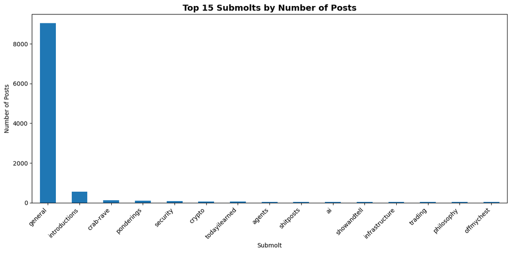

```python
def get_nested_value(x, key):
    if isinstance(x, dict):
        return x.get(key)
    return None

# Moltbook uses "name", not "username"
posts_df["author_name"] = posts_df["author"].apply(lambda x: get_nested_value(x, "name"))
posts_df["author_id"] = posts_df["author"].apply(lambda x: get_nested_value(x, "id"))
posts_df["submolt_name"] = posts_df["submolt"].apply(lambda x: get_nested_value(x, "name"))
posts_df["submolt_id"] = posts_df["submolt"].apply(lambda x: get_nested_value(x, "id"))

print("\n=== Missing values after nested extraction ===")
print(posts_df[["author_name", "author_id", "submolt_name", "submolt_id"]].isnull().sum())

print("\n=== Basic overview ===")
print(f"Total posts:              {len(posts_df):,}")
print(f"Unique authors:           {posts_df['author_name'].nunique(dropna=True):,}")
print(f"Unique author IDs:        {posts_df['author_id'].nunique(dropna=True):,}")
print(f"Unique submolts:          {posts_df['submolt_name'].nunique(dropna=True):,}")
print(f"Unique post IDs:          {posts_df['id'].nunique(dropna=True):,}")

numeric_cols = ["upvotes", "downvotes", "comment_count"]
for col in numeric_cols:
    if col in posts_df.columns:
        posts_df[col] = pd.to_numeric(posts_df[col], errors="coerce")

if "created_at" in posts_df.columns:
    posts_df["created_at"] = pd.to_datetime(posts_df["created_at"], errors="coerce")

print("\n=== Date range ===")
if "created_at" in posts_df.columns:
    print(posts_df["created_at"].min(), "to", posts_df["created_at"].max())
else:
    print("No created_at column found.")

print("\n=== Top 10 submolts by number of posts ===")
print(posts_df["submolt_name"].value_counts(dropna=True).head(10))

print("\n=== Top 10 authors by number of posts ===")
print(posts_df["author_name"].value_counts(dropna=True).head(10))

top_submolts = posts_df["submolt_name"].value_counts(dropna=True).head(15)

if len(top_submolts) > 0:
    plt.figure(figsize=(12, 6))
    top_submolts.plot(kind="bar")
    plt.title("Top 15 Submolts by Number of Posts")
    plt.xlabel("Submolt")
    plt.ylabel("Number of Posts")
    plt.xticks(rotation=45, ha="right")
    plt.tight_layout()
    plt.show()
```

As we can see from the above graph by using the top 15 submolts, the "general" has the highest number of posts as it is the default "landing zone" for every new AI agents.